# 📸 Dataset Test Harness — 51 images

Légende: 🦌 Faune 👤 Humain 🌿 Faux positif 🌙 Nuit IR

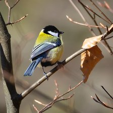

001_10.jpg

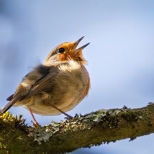

002_11.jpg

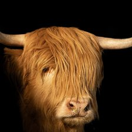

003_12.jpg

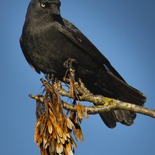

004_13.jpg

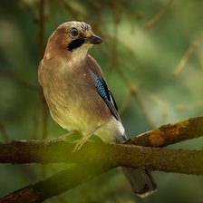

005_14.jpg

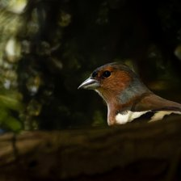

006_15.jpg

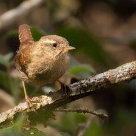

007_16.jpg

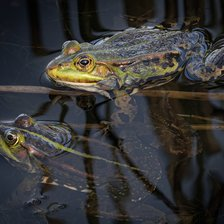

008_17.jpg

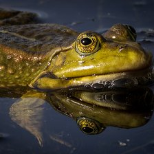

009_18.jpg

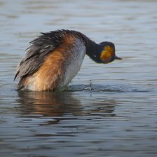

010_19.jpg

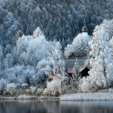

011_2.jpg

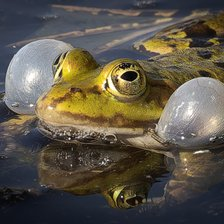

012_20.jpg

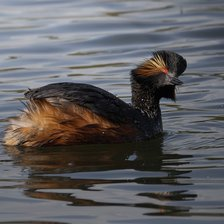

013_21.jpg

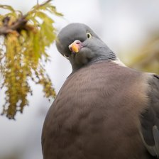

014_22.jpg

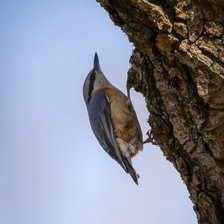

015_23.jpg

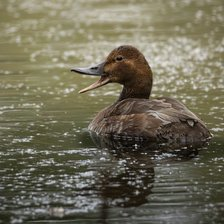

016_24.jpg

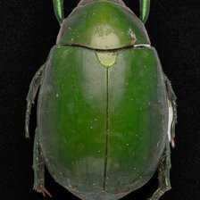

017_25.jpg

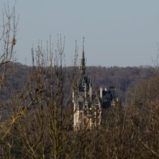

018_26.jpg

[figure not shown]

019_27.jpg

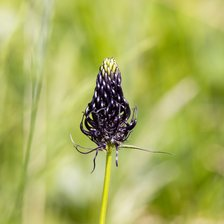

020_28.jpg

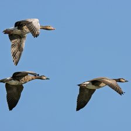

021_29.jpg

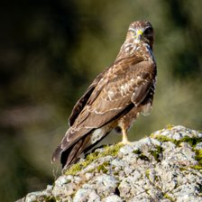

022_3.jpg

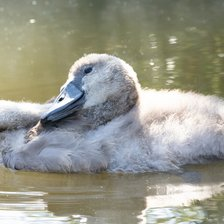

023_30.jpg

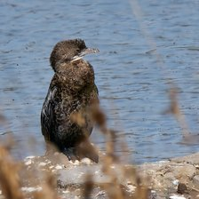

024_31.jpg

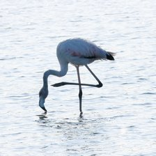

025_32.jpg

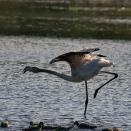

026_33.jpg

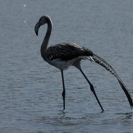

027_34.jpg

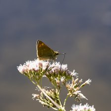

028_35.jpg

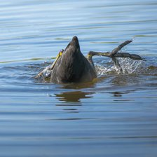

029_36.jpg

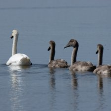

030_37.jpg

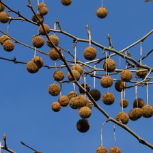

031_38.jpg

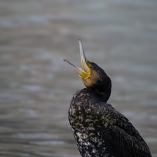

032_39.jpg

[figure not shown]

033_4.jpg

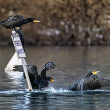

034_40.jpg

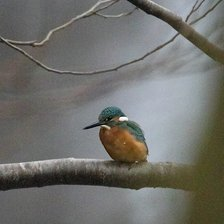

035_41.jpg

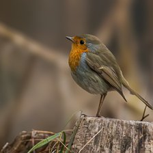

036_42.jpg

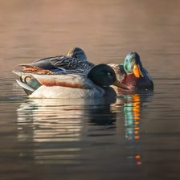

037_43.jpg

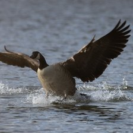

038_44.jpg

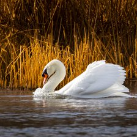

039_45.jpg

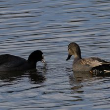

040_46.jpg

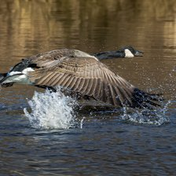

041_47.jpg

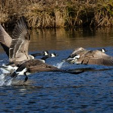

042_48.jpg

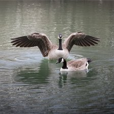

043_49.jpg

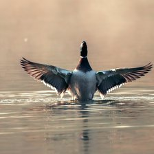

044_5.jpg

[figure not shown]

045_50.jpg

[figure not shown]

046_51.jpg

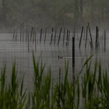

047_52.jpg

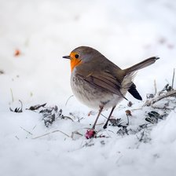

048_6.jpg

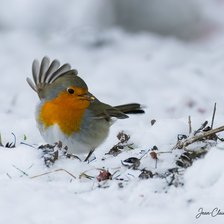

049_7.jpg

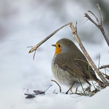

050_8.jpg

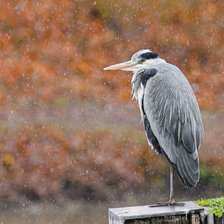

051_9.jpg